# Installing OpenCV for Conda Virtual Environments

Rob Williams

12/20/2018

This tutorial is an addendum to Adrian Rosebrock’s [fantastic tutorial](https://www.pyimagesearch.com/2018/08/17/install-opencv-4-on-macos/) on installing OpenCV from source on Mac OS.[^1] His tutorial does an excellent job showing you how to install OpenCV for a Homebrew Python virtual environment. However, I prefer to use Anaconda to manage my Python virtual environments, so I wrote this tutorial for others who are looking to install OpenCV for Anaconda Python.

## Installation

Follow the steps in Adrian’s tutorial up until executing the `cmake` command. Instead, execute the following commands (adjusting the Python version as necessary):

```bash
export CPLUS_INCLUDE_PATH=<path to conda env>/lib/python3.6

cmake -D CMAKE_BUILD_TYPE=RELEASE \
    -D CMAKE_INSTALL_PREFIX=/usr/local \
    -D OPENCV_EXTRA_MODULES_PATH=<path to conda opencv_contrib>/opencv_contrib/modules \
    -D PYTHON3_LIBRARY=<path to conda env>/lib/python3.6m.dylib \
    -D PYTHON3_INCLUDE_DIR=<path to conda env>/include/python3.6m \
    -D PYTHON3_EXECUTABLE=<path to conda env>/bin/python \
    -D PYTHON3_PACKAGES_PATH=<path to conda env>/lib/python3.6/site-packages \
    -D BUILD_opencv_python2=OFF \
    -D BUILD_opencv_python3=ON \
    -D INSTALL_PYTHON_EXAMPLES=ON \
    -D INSTALL_C_EXAMPLES=OFF \
    -D OPENCV_ENABLE_NONFREE=ON \
    -D BUILD_EXAMPLES=ON ..
```

The first line tells `cmake` where to find C++ headers for your virtual environment. On my system, compiling OpenCV (from source directories in my home directory) for a Conda virtual environment called `cv` for a Miniconda installation located in my home directory looks like this:

```bash
export CPLUS_INCLUDE_PATH=~/miniconda3/envs/cv/lib/python3.6

cmake -D CMAKE_BUILD_TYPE=RELEASE \
    -D CMAKE_INSTALL_PREFIX=/usr/local \
    -D OPENCV_EXTRA_MODULES_PATH=~/opencv_contrib/modules \
    -D PYTHON3_LIBRARY=~/miniconda3/envs/cv/lib/python3.6m.dylib \
    -D PYTHON3_INCLUDE_DIR=~/miniconda3/envs/cv/include/python3.6m \
    -D PYTHON3_EXECUTABLE=~/miniconda3/envs/cv/bin/python \
    -D PYTHON3_PACKAGES_PATH=~/miniconda3/envs/cv/lib/python3.6/site-packages \
    -D BUILD_opencv_python2=OFF \
    -D BUILD_opencv_python3=ON \
    -D INSTALL_PYTHON_EXAMPLES=ON \
    -D INSTALL_C_EXAMPLES=OFF \
    -D OPENCV_ENABLE_NONFREE=ON \
    -D BUILD_EXAMPLES=ON ..
```

From here, execute the `make` command with the appropriate flag for the number of cores to use:

```bash
make -j4
```

After `make` finishes, install OpenCV:

```bash
sudo make install
```

From there, symlink OpenCV into your Anaconda environment:

```bash
cd <path to conda env>/lib/python3.6
ln -s /usr/local/python/cv2 cv2
```

## Testing

And you should be good to go! The Python code below demonstrates that OpenCV is successfully installed with non-free algorithms included.

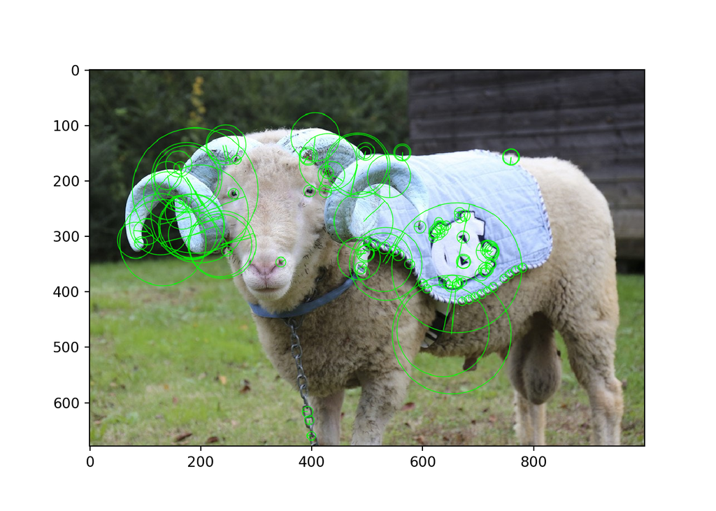

```python
import cv2
import matplotlib.pyplot as plt
# load image
img = cv2.imread('rameses.jpg')
# convert to grayscale
img_gray = cv2.cvtColor(img, cv2.COLOR_BGR2GRAY)
# instantiate SURF
surf = cv2.xfeatures2d.SURF_create(7000)
# compute keypoints
kp = surf.detect(img_gray, None)
# plot keypoints
plt.imshow(cv2.drawKeypoints(cv2.cvtColor(img, cv2.COLOR_BGR2RGB), kp, None, (0,255,0), 4))
plt.show()
```

[^1]: Thanks to [Michelle Torres](http://smtorres.org/) for pointing me to this tutorial.